# iFood Data Analyst Case

## by Jean Carlos da Cruz

cruzjeanc@gmail.com - https://www.linkedin.com/in/jeanccruz1/

- Introduction
- Gather
- Assess
- Clean
- EDA (Exploratory Data Analysis)
1. What is the distribution of ages in the dataset?
2. What kind of Marital_Status has more purchases?
3. What kind of Education has more purchases?
4. What kind of Marital_Status spends more on purchases?
5. What kind of Education spends more on purchases?
6. Is there any predominant Product by amount purchased?
7. Is there any predominant Sales Channel by number of purchases?
- Customer Segmentation
- Predictive Model (Classification)

## Introduction

> A well-established company operating in the retail food sector. Presently they have around several hundred thousand registered customers and serve almost one million consumers a year. Globally, the company had solid revenues and a healthy bottom line in the past 3 years, but the profit growth perspectives for the next 3 years are not promising... For this reason, several strategic initiatives are being considered to invert this situation. One is to improve the performance of marketing activities, with a special focus on marketing campaigns.The objective here is to build a predictive model that will produce the highest profit for the next direct marketing campaign, scheduled for the next month. The new campaign, aims at selling a new gadget to the Customer Database. To build the model, a pilot campaign involving 2.240 customers was carried out. The customers were selected at random and contacted by phone regarding the acquisition of the gadget. During the following months, customers who bought the offer were properly labeled.

### The Data

> The data set contains socio-demographic and firmographic features about 2.240 customers who were contacted. Additionally, it contains a flag for those customers who responded the campaign, by buying the product.

## EDA (Exploratory Data Analysis)

### 1. What is the distribution of ages in the dataset?

> After removing some outliers (3 Users with more than 120 years). From total 2213 users, the average age of users in dataset is 52 years, with the minimum age being 25 and the maximum 81 years.

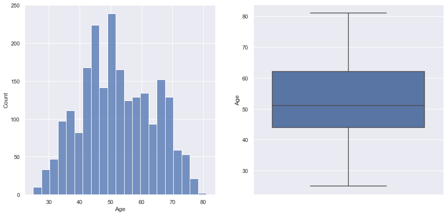

```python
#Plotting the Distribution of Ages again after removinf the outliers
fig, ax = plt.subplots(1, 2, figsize=(15, 7))
sns.histplot(data=df, x="Age", ax=ax[0])
sns.boxplot(y='Age', data=df, ax=ax[1])
fig.show()
```

### 2. What kind of Marital_Status has more purchases in total?

> Married users is the group with more purchases among all others. Actually, people that are somehow together are listed as the second one when it comes to purchases. So we can assume that in general people in a relantionship make more purchases.

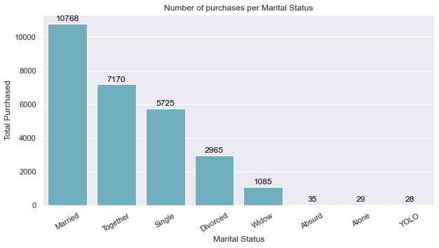

```python
#Ploting the results in a bar chart
f,ax = plt.subplots(figsize=(10, 5))
chart = sns.barplot(x='Marital_Status', y='Total_Purchases' , data=df_marital_status2, color='c')
chart.set(title='Number of purchases per Marital Status', xlabel='Marital Status', ylabel="Total Purchased")
chart.set_xticklabels(chart.get_xticklabels(), rotation=30)
# Getting Labels
for p in chart.patches:
             chart.annotate("%.0f" % p.get_height(), (p.get_x() + p.get_width() / 2., p.get_height()),
                 ha='center', va='center', fontsize=12, color='black', xytext=(0, 7),
                 textcoords='offset points')
plt.show()
```

### 3. What kind of Education has more purchases in total?

> When it comes to Number of purchases per education degree, people that are marked as Graduation have the highest number of purchases.

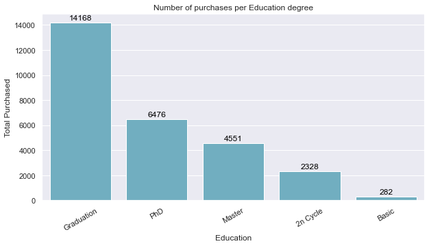

```python
#Ploting the results in a bar chart
f,ax = plt.subplots(figsize=(10, 5))
chart = sns.barplot(x='Education', y='Total_Purchases' , data=df_education2, color='c')
chart.set(title='Number of purchases per Education degree', xlabel='Education', ylabel="Total Purchased")
chart.set_xticklabels(chart.get_xticklabels(), rotation=30)
# Getting Labels
for p in chart.patches:
             chart.annotate("%.0f" % p.get_height(), (p.get_x() + p.get_width() / 2., p.get_height()),
                 ha='center', va='center', fontsize=12, color='black', xytext=(0, 7),
                 textcoords='offset points')
plt.show()
```

## This groups that have more purchases are also the ones that have the highest number of users in the dataset???

> As expected the groups with more purchases when it comes to Education and Marital Status are also the ones with the highest number of users. So in order to have more accurate results we should consider number of purchases per user instead of total.

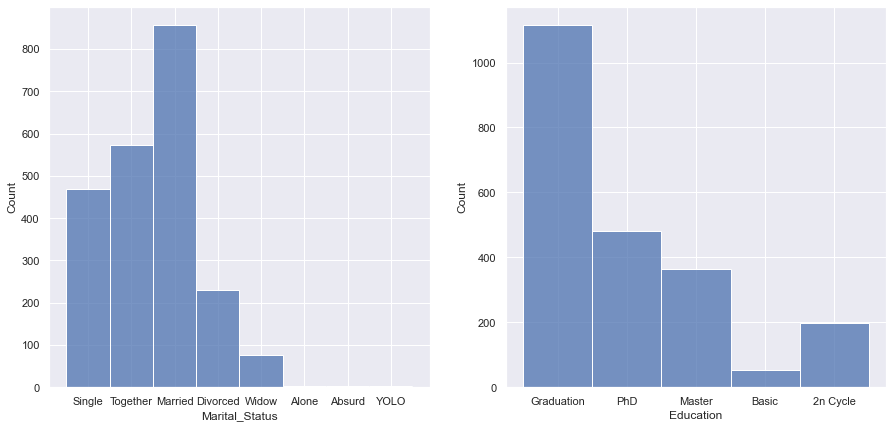

```python
#Plotting the Distribution of Marital Status and Education
fig, ax = plt.subplots(1, 2, figsize=(15, 7))
sns.histplot(data=df, x="Marital_Status", ax=ax[0])
sns.histplot(data=df, x="Education", ax=ax[1])
fig.show()
```

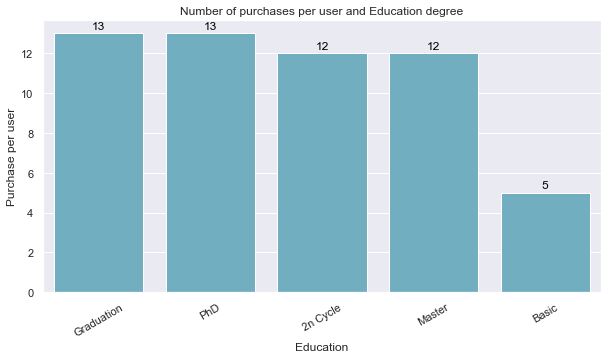

```python
#Ploting the results in a bar chart
f,ax = plt.subplots(figsize=(10, 5))
chart = sns.barplot(x='Education', y='Purchases_per_user' , data=df_education_grouped2, color='c')
chart.set(title='Number of purchases per user and Education degree', xlabel='Education', ylabel="Purchase per user")
chart.set_xticklabels(chart.get_xticklabels(), rotation=30)
# Getting Labels
for p in chart.patches:
             chart.annotate("%.0f" % p.get_height(), (p.get_x() + p.get_width() / 2., p.get_height()),
                 ha='center', va='center', fontsize=12, color='black', xytext=(0, 7),
                 textcoords='offset points')
plt.show()
```

#### Now the results are pretty different and make more sense. Users marked as Graduation still have the highest number of purchases made, but other groups are now showing similar results. Only users in Basic Group have small number or purchases per user when compared to others. Let's see if we get the same outcome regarding Marital Status!

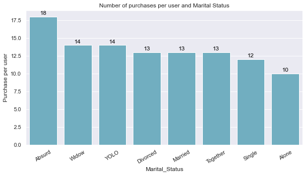

```python
#Ploting the results in a bar chart
f,ax = plt.subplots(figsize=(10, 5))
chart = sns.barplot(x='Marital_Status', y='Purchases_per_user' , data=df_marital_grouped2, color='c')
chart.set(title='Number of purchases per user and Marital Status', xlabel='Marital_Status', ylabel="Purchase per user")
chart.set_xticklabels(chart.get_xticklabels(), rotation=30)
# Getting Labels
for p in chart.patches:
             chart.annotate("%.0f" % p.get_height(), (p.get_x() + p.get_width() / 2., p.get_height()),
                 ha='center', va='center', fontsize=12, color='black', xytext=(0, 7),
                 textcoords='offset points')
plt.show()
```

### Now the results are totally different than before. I have no idea what a Absurd Marital Status means but they are in our dataset the ones with the highest number of purchases per user. Of course the sample size is not big enough to make any conclusions (only 2 users) we should dig deeper into this to see if this group has any potential. All other Marital Status have pretty similar number of purchases per user.

### 4. What kind of Marital_Status spends more on purchases?

> Once again this Absurd Marital Status (Still no idea what that means!!!) have the highest amount spent among all other groups. Still we need to take into consideration that the sample size is quite small. The second group with the highest spend is the Widow group. Maybe afther their loss they have more money or time to buy products? This could be interesting to dig deep.

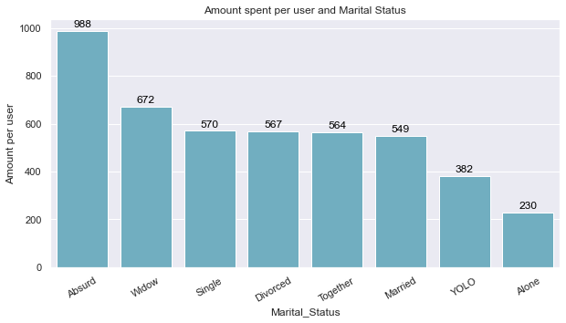

```python
#Ploting the results in a bar chart
f,ax = plt.subplots(figsize=(10, 5))
chart = sns.barplot(x='Marital_Status', y='Mnt_per_user' , data=df_marital_mnt_spent2, color='c')
chart.set(title='Amount spent per user and Marital Status', xlabel='Marital_Status', ylabel="Amount per user")
chart.set_xticklabels(chart.get_xticklabels(), rotation=30)
# Getting Labels
for p in chart.patches:
             chart.annotate("%.0f" % p.get_height(), (p.get_x() + p.get_width() / 2., p.get_height()),
                 ha='center', va='center', fontsize=12, color='black', xytext=(0, 7),
                 textcoords='offset points')
plt.show()
```

### 5. What kind of Education spends more on purchases?

> Users with PhD spend more per user than other groups. Altough they don't have the highest number of purchases they have the highest amount, which means they are big spenders of our products. This means we should focus on them now on.

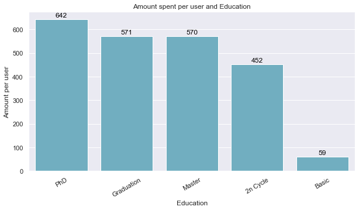

```python
#Ploting the results in a bar chart
f,ax = plt.subplots(figsize=(10, 5))
chart = sns.barplot(x='Education', y='Mnt_per_user' , data=df_education_spent2, color='c')
chart.set(title='Amount spent per user and Education', xlabel='Education', ylabel="Amount per user")
chart.set_xticklabels(chart.get_xticklabels(), rotation=30)
# Getting Labels
for p in chart.patches:
             chart.annotate("%.0f" % p.get_height(), (p.get_x() + p.get_width() / 2., p.get_height()),
                 ha='center', va='center', fontsize=12, color='black', xytext=(0, 7),
                 textcoords='offset points')
plt.show()
```

### 6. Is there any predominant Product by amount purchased?

> Users within this dataset really like our wines. The amount spent on Wines is almost twice the spent on the second product which is meat. Is it Wine our main product when it comes to marketing? I don't know but people seens to like it!!!

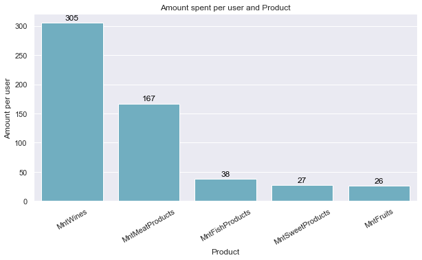

```python
#Ploting the results in a bar chart
f,ax = plt.subplots(figsize=(10, 5))
chart = sns.barplot(x='Product', y='Mnt_per_user' , data=df_Product_spent2, color='c')
chart.set(title='Amount spent per user and Product', xlabel='Product', ylabel="Amount per user")
chart.set_xticklabels(chart.get_xticklabels(), rotation=30)
# Getting Labels
for p in chart.patches:
             chart.annotate("%.0f" % p.get_height(), (p.get_x() + p.get_width() / 2., p.get_height()),
                 ha='center', va='center', fontsize=12, color='black', xytext=(0, 7),
                 textcoords='offset points')
plt.show()
```

### 7. Is there any predominant Sales Channel by number of purchases?

> Probabily this dataset it is from before pandemic, the number of Store Purchases per user is 50% higher than Web's.

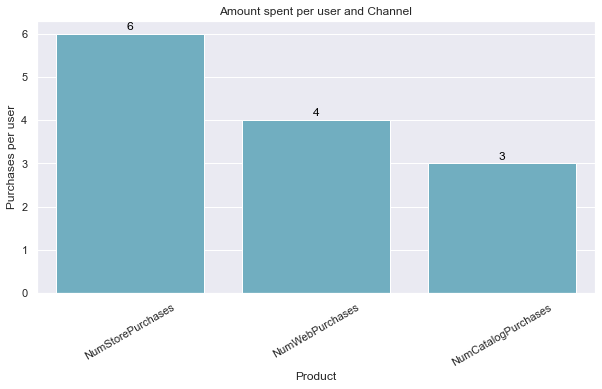

```python
#Ploting the results in a bar chart
f,ax = plt.subplots(figsize=(10, 5))
chart = sns.barplot(x='Channel', y='Purchases_per_user' , data=df_Channel_spent2, color='c')
chart.set(title='Amount spent per user and Channel', xlabel='Product', ylabel="Purchases per user")
chart.set_xticklabels(chart.get_xticklabels(), rotation=30)
# Getting Labels
for p in chart.patches:
             chart.annotate("%.0f" % p.get_height(), (p.get_x() + p.get_width() / 2., p.get_height()),
                 ha='center', va='center', fontsize=12, color='black', xytext=(0, 7),
                 textcoords='offset points')
plt.show()
```

## Customer Segmentation

> RFM (Recency, Frequency, Monetary) analysis is a behavior-based approach grouping customers into segments. It groups the customers on the basis of their previous purchase transactions. How recently, how often, and how much did a customer buy. RFM filters customers into various groups for the purpose of better service. It helps managers to identify potential customers to do more profitable business. There is a segment of customer who is the big spender but what if they purchased only once or how recently they purchased? Do they often purchase our product? Also, It helps managers to run an effective promotional campaign for personalized service.  
> Recency (R): Who have purchased recently? Number of days since last purchase (least recency)  
> Frequency (F): Who has purchased frequently? It means the total number of purchases. ( high frequency)  
> Monetary Value(M): Who have high purchase amount? It means the total money customer spent (high monetary value)  
> More concepts on: https://www.optimove.com/resources/learning-center/rfm-segmentation

#### Customers with the lowest recency, highest Total_Purchases and Total_Mnt_Spent will be considered as our top customers.

> qcut() is Quantile-based discretization function. qcut bins the data based on sample quantiles. For example, 1000 values for 4 quantiles would produce a categorical object indicating quantile membership for each customer.

```python
#Combining all quartiles into a single column
df_segmentation_filter['RFM_Score'] = df_segmentation_filter.Recency_quartile.astype(str)+ df_segmentation_filter.Total_Purchases_quartile.astype(str) + df_segmentation_filter.Total_Mnt_Spent_quartile.astype(str)
df_segmentation_filter.head()
```

|  | ID | Recency | Total_Purchases | Total_Mnt_Spent | Recency_quartile | Total_Purchases_quartile | Total_Mnt_Spent_quartile | RFM_Score |
| --- | --- | --- | --- | --- | --- | --- | --- | --- |
| 0 | 5524 | 58 | 22 | 1529 | 3 | 1 | 1 | 311 |
| 1 | 2174 | 38 | 4 | 21 | 2 | 4 | 4 | 244 |
| 2 | 4141 | 26 | 20 | 734 | 2 | 1 | 2 | 212 |
| 3 | 6182 | 26 | 6 | 48 | 2 | 4 | 4 | 244 |
| 4 | 5324 | 94 | 14 | 407 | 4 | 2 | 2 | 422 |

The RFM_Score is defined by the concatenate of the three quartiles. But we end up with 47 that is a pretty big number when it comes to segments. Let's reduce this number by summing the scores!

```python
#Creating a second RFM_Score by summing our scores into a single number
df_segmentation_filter['RFM_Score_2'] = df_segmentation_filter.Recency_quartile.astype(int)+ df_segmentation_filter.Total_Purchases_quartile.astype(int) + df_segmentation_filter.Total_Mnt_Spent_quartile.astype(int)
df_segmentation_filter.head()
```

|  | ID | Recency | Total_Purchases | Total_Mnt_Spent | Recency_quartile | Total_Purchases_quartile | Total_Mnt_Spent_quartile | RFM_Score | RFM_Score_2 |
| --- | --- | --- | --- | --- | --- | --- | --- | --- | --- |
| 0 | 5524 | 58 | 22 | 1529 | 3 | 1 | 1 | 311 | 5 |
| 1 | 2174 | 38 | 4 | 21 | 2 | 4 | 4 | 244 | 10 |
| 2 | 4141 | 26 | 20 | 734 | 2 | 1 | 2 | 212 | 5 |
| 3 | 6182 | 26 | 6 | 48 | 2 | 4 | 4 | 244 | 10 |
| 4 | 5324 | 94 | 14 | 407 | 4 | 2 | 2 | 422 | 8 |

The second RFM_Score is defined by the sum of the three quartiles. Now we have 10 segments, which are still a lot. So we are going to create RFM_Levels. Defined as:  
Can't Loose Them  
Champions  
Loyal  
Needs Attention  
Potential  
Promising  
Require Activation

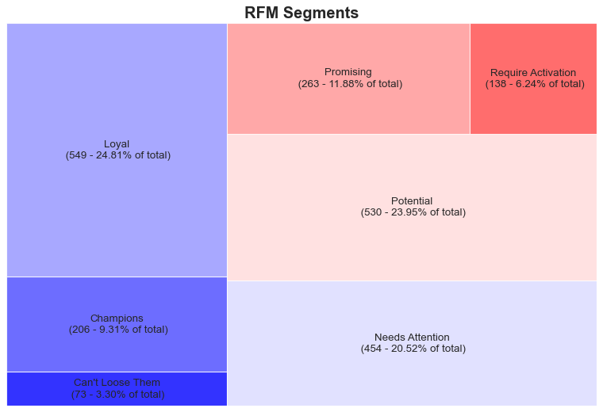

```python
#Creating a treemap to better see the results
labels = df_rfm_level_agg.apply(lambda x: str(x[0]) + "\n (" + str(x[4]) + " - " + str(x[7]) + " of total" ")" , axis=1)
sizes = df_rfm_level_agg['Count'].values.tolist()
colors = [plt.cm.bwr(i/float(len(df_rfm_level_agg['RFM_Score']))) for i in range(len(df_rfm_level_agg['RFM_Score']))]

# Draw Plot
plt.figure(figsize=(12,8), dpi= 80)
squarify.plot(sizes=sizes, label=labels, color=colors, alpha=.8)

# Decorate
plt.title("RFM Segments",fontsize=18,fontweight="bold")
plt.axis('off')
plt.show()
```

### After the RFM Segmentation we endup with 7 segments for our clients, where 3.3% of them are reay good customers and we should not loose them. And we have 138 customers (6.24% of total) that require activation within our products and services.

## Predictive Model (Classification)

> Logistic Regression is a Machine Learning classification algorithm that is used to predict the probability of a categorical dependent variable. In logistic regression, the dependent variable is a binary variable that contains data coded as 1 (yes, success, etc.) or 0 (no, failure, etc.). In other words, the logistic regression model predicts P(Y=1) as a function of X.

```python
count_no_sub = len(df_classification[df_classification['Response']==0])
count_sub = len(df_classification[df_classification['Response']==1])
pct_of_no_sub = count_no_sub/(count_no_sub+count_sub)
print("The Percentage of customers that their Response is positive in our dataset is", pct_of_no_sub*100)
pct_of_sub = count_sub/(count_no_sub+count_sub)
print("The Percentage of customers that their Response is negative in our dataset is", pct_of_sub*100)
```

```
The Percentage of customers that their Response is positive in our dataset is 84.95255309534568
The Percentage of customers that their Response is negative in our dataset is 15.047446904654315
```

Our Responses are imbalanced, and the ratio of no-response to response instances is 85:15. We will need to balance the classes further on.

```python
#Over smapling using smote
from imblearn.over_sampling import SMOTE
from sklearn.model_selection import train_test_split

os = SMOTE(random_state=0)
columns = X.columns

os_data_X,os_data_y=os.fit_resample(X, y)
os_data_X = pd.DataFrame(data=os_data_X,columns=columns )
os_data_y= pd.DataFrame(data=os_data_y,columns=['Response'])
# we can Check the numbers of our data
print("Length of dataset after the Oversampling Techinique is ",len(os_data_X))
print("Number of no response in oversampled data",len(os_data_y[os_data_y['Response']==0]))
print("Number of response",len(os_data_y[os_data_y['Response']==1]))
print("Proportion of no response data in oversampled data is ",len(os_data_y[os_data_y['Response']==0])/len(os_data_X))
print("Proportion of response data in oversampled data is ",len(os_data_y[os_data_y['Response']==1])/len(os_data_X))
```

```
Length of dataset after the Oversampling Techinique is  3760
Number of no response in oversampled data 1880
Number of response 1880
Proportion of no response data in oversampled data is  0.5
Proportion of response data in oversampled data is  0.5
```

Now we have a balanced training dataset!

### Recursive Feature Elimination

> We will use Recursive Feature Elimination (RFE) to repeatedly construct a model and choose either the best or worst performing feature, setting the feature aside and then repeating the process with the rest of the features. This process is applied until all features in the dataset are exhausted. The goal of RFE is to select features by recursively considering smaller and smaller sets of features.

```python
#Implementing the model
import statsmodels.api as sm
logit_model=sm.Logit(os_data_y,new_os_data_X)
result=logit_model.fit()
print(result.summary2())
```

```
Optimization terminated successfully.
         Current function value: 0.313443
         Iterations 8
                             Results: Logit
========================================================================
Model:                  Logit              Pseudo R-squared:   0.548
Dependent Variable:     Response           AIC:                2397.0907
Date:                   2021-09-03 16:27   BIC:                2521.7341
No. Observations:       3760               Log-Likelihood:     -1178.5
Df Model:               19                 LL-Null:            -2606.2
Df Residuals:           3740               LLR p-value:        0.0000
Converged:              1.0000             Scale:              1.0000
No. Iterations:         8.0000
------------------------------------------------------------------------
                         Coef.  Std.Err.    z     P>|z|   [0.025  0.975]
------------------------------------------------------------------------
Kidhome                 -0.1902   0.1362  -1.3963 0.1626 -0.4571  0.0768
Teenhome                -1.1773   0.1200  -9.8142 0.0000 -1.4124 -0.9422
NumCatalogPurchases      0.4260   0.0221  19.2438 0.0000  0.3826  0.4694
NumWebVisitsMonth        0.5945   0.0271  21.9185 0.0000  0.5413  0.6476
AcceptedCmp3             0.8706   0.1923   4.5263 0.0000  0.4936  1.2475
AcceptedCmp4             0.0166   0.2234   0.0743 0.9408 -0.4212  0.4544
AcceptedCmp5             1.8929   0.2019   9.3732 0.0000  1.4971  2.2887
AcceptedCmp1             1.0221   0.2133   4.7922 0.0000  0.6041  1.4402
AcceptedCmp2             0.7333   0.4772   1.5366 0.1244 -0.2020  1.6686
Complain                -0.5649   0.9071  -0.6228 0.5334 -2.3429  1.2130
Education_2n Cycle      -3.3448   0.2853 -11.7237 0.0000 -3.9040 -2.7856
Education_Basic         -4.7860   0.7612  -6.2877 0.0000 -6.2779 -3.2941
Education_Graduation    -2.5486   0.1631 -15.6245 0.0000 -2.8683 -2.2289
Education_Master        -2.3639   0.2013 -11.7442 0.0000 -2.7584 -1.9694
Education_PhD           -1.8534   0.1797 -10.3134 0.0000 -2.2057 -1.5012
Marital_Status_Divorced -2.8765   0.2207 -13.0326 0.0000 -3.3091 -2.4439
Marital_Status_Married  -3.4912   0.1751 -19.9330 0.0000 -3.8345 -3.1480
Marital_Status_Single   -2.4235   0.1676 -14.4631 0.0000 -2.7519 -2.0951
Marital_Status_Together -3.8360   0.2020 -18.9890 0.0000 -4.2319 -3.4401
Marital_Status_Widow    -2.5488   0.3101  -8.2200 0.0000 -3.1566 -1.9411
========================================================================
```

The p-values for most of the variables are smaller than 0.05, except four variables, therefore, we will remove them.

```python
#Implementing the model again
import statsmodels.api as sm
logit_model=sm.Logit(os_data_y,new_os_data_X_2)
result=logit_model.fit()
print(result.summary2())
```

```
Optimization terminated successfully.
         Current function value: 0.314173
         Iterations 8
                             Results: Logit
========================================================================
Model:                  Logit              Pseudo R-squared:   0.547
Dependent Variable:     Response           AIC:                2394.5822
Date:                   2021-09-03 16:27   BIC:                2494.2970
No. Observations:       3760               Log-Likelihood:     -1181.3
Df Model:               15                 LL-Null:            -2606.2
Df Residuals:           3744               LLR p-value:        0.0000
Converged:              1.0000             Scale:              1.0000
No. Iterations:         8.0000
------------------------------------------------------------------------
                         Coef.  Std.Err.    z     P>|z|   [0.025  0.975]
------------------------------------------------------------------------
Teenhome                -1.1409   0.1167  -9.7729 0.0000 -1.3697 -0.9121
NumCatalogPurchases      0.4378   0.0208  21.0261 0.0000  0.3969  0.4786
NumWebVisitsMonth        0.5818   0.0253  23.0196 0.0000  0.5322  0.6313
AcceptedCmp3             0.8657   0.1904   4.5473 0.0000  0.4926  1.2388
AcceptedCmp5             1.9383   0.1960   9.8898 0.0000  1.5542  2.3225
AcceptedCmp1             1.0396   0.2109   4.9291 0.0000  0.6262  1.4530
Education_2n Cycle      -3.3555   0.2841 -11.8117 0.0000 -3.9123 -2.7987
Education_Basic         -4.8093   0.7622  -6.3095 0.0000 -6.3032 -3.3153
Education_Graduation    -2.5764   0.1623 -15.8697 0.0000 -2.8946 -2.2582
Education_Master        -2.4034   0.1997 -12.0324 0.0000 -2.7949 -2.0119
Education_PhD           -1.8680   0.1792 -10.4235 0.0000 -2.2192 -1.5168
Marital_Status_Divorced -2.8956   0.2195 -13.1930 0.0000 -3.3257 -2.4654
Marital_Status_Married  -3.5283   0.1742 -20.2526 0.0000 -3.8697 -3.1868
Marital_Status_Single   -2.4555   0.1666 -14.7375 0.0000 -2.7821 -2.1289
Marital_Status_Together -3.8529   0.2007 -19.1981 0.0000 -4.2463 -3.4596
Marital_Status_Widow    -2.5535   0.3090  -8.2626 0.0000 -3.1592 -1.9478
========================================================================
```

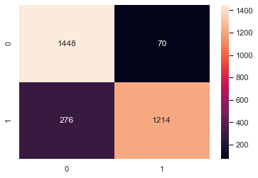

```python
#Checking the predictions in the training dataset
y_predict_train = logreg.predict(X_train)
from sklearn.metrics import classification_report, confusion_matrix
cm = confusion_matrix(y_train, y_predict_train)
sns.heatmap(cm, annot=True, fmt="d")
```

The result is telling us that we have 2662 (1448+1214) correct predictions and 346 (276+70) incorrect predictions in the training dataset.

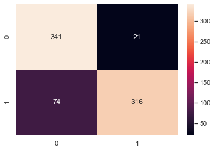

```python
#Checking the predictions in the test dataset
y_predict_train = logreg.predict(X_test)
from sklearn.metrics import classification_report, confusion_matrix
cm = confusion_matrix(y_test, y_pred)
sns.heatmap(cm, annot=True, fmt="d")
```

The result is telling us that we have 657 (341+316) correct predictions and 95 (74+21) incorrect predictions in the test dataset.

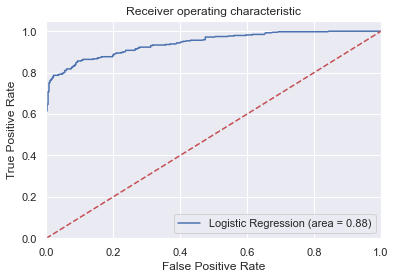

```python
#ROC Curve
from sklearn.metrics import roc_auc_score
from sklearn.metrics import roc_curve
logit_roc_auc = roc_auc_score(y_test, logreg.predict(X_test))
fpr, tpr, thresholds = roc_curve(y_test, logreg.predict_proba(X_test)[:,1])
plt.figure()
plt.plot(fpr, tpr, label='Logistic Regression (area = %0.2f)' % logit_roc_auc)
plt.plot([0, 1], [0, 1],'r--')
plt.xlim([0.0, 1.0])
plt.ylim([0.0, 1.05])
plt.xlabel('False Positive Rate')
plt.ylabel('True Positive Rate')
plt.title('Receiver operating characteristic')
plt.legend(loc="lower right")
plt.savefig('Log_ROC')
plt.show()
```

The receiver operating characteristic (ROC) curve is another common tool used with binary classifiers. The dotted line represents the ROC curve of a purely random classifier; a good classifier stays as far away from that line as possible (toward the top-left corner).

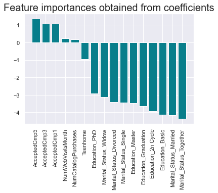

```python
# logistic regression for feature importance
from sklearn.linear_model import LogisticRegression

model = LogisticRegression()
model.fit(X_train, y_train)
importances = pd.DataFrame(data={
    'Attribute': X_train.columns,
    'Importance': model.coef_[0]
})
importances = importances.sort_values(by='Importance', ascending=False)
plt.bar(x=importances['Attribute'], height=importances['Importance'], color='#087E8B')
plt.title('Feature importances obtained from coefficients', size=20)
plt.xticks(rotation='vertical')
plt.show()
```

The larger the coefficient is (in both positive and negative direction), the more influence it has on a prediction.